# Plan du Notebook

**Étudiantes à l'UEVE en M2DS :** Fatima-Zahra Aklila, Samira Sonfack

**Projet :** Projet de Machine Learning Prédiction du taux d'engagement ”Churn Rate” des clients d’une companie de téléphonie mobile

**Date :** 15 Décembre 2025

1. Partie préliminaire : Business
   1. Description du contexte et du besoin
   2. Description du tableau des données : signification de chaque variable (entrées) et la variable cible (target)
2. Partie Data Science
   1. Préparation des données
      - Pré-traitement pour l’exploration : nettoyage et encodage
   2. Exploration statistique des données
      - Visualisation des données
      - Tests d’hypothèses
   3. Définition des métriques
      - Choix des métriques pour sélectionner le modèle le plus adéquat
   4. Sans sélection des variables
      - Préparation des données pour l’entraînement
      - Entraînement et test des modèles
      - Validation des modèles et choix du modèle le plus adéquat
   5. Avec sélection de variables
      - Comparaison des performances des modèles
3. Partie Amélioration
   1. Amélioration du meilleur modèle
   2. Entrainement du meilleur modèle avec des données augmentées
4. Bilan et conclusion

## Partie Préliminaire : Business

1. Description du contexte et du besoin :

L’objectif de ce projet est de **conseiller le directeur d’un opérateur de téléphonie mobile** dans la **prédiction du taux de churn (attrition)** de son entreprise à partir du jeu de données **celldata.csv**.

Ce jeu de données contient **8 000 observations** et se compose de :

- **La variable cible :**
  - *Churn* ∈ {0, 1}
- **p = 10 variables explicatives :**
  - **CreditScore** (quantitative)
  - **Geography** (qualitative)
  - **Gender** (qualitative)
  - **Age** (quantitative)
  - **Tenure** (quantitative)
  - **Balance** (quantitative)
  - **NumOfProducts** (quantitative)
  - **HasCrCard** (binaire : {0,1})
  - **IsActiveMember** (binaire : {0,1})
  - **Salary** (quantitative)

## Partie Data Science

- **Importation des packages nécessaires :**
- **Téléchargement des données**

|  | CreditScore | Geography | Gender | Age | Tenure | Balance | NumOfProducts | HasCrCard | IsActiveMember | Salary | Churn |
| --- | --- | --- | --- | --- | --- | --- | --- | --- | --- | --- | --- |
| 0 | 632 | Germany | Female | 50 | 5 | 107959.39 | 1 | 1 | 1 | 6985 | 1 |
| 1 | 649 | France | Female | 42 | 7 | 0.00 | 2 | 0 | 1 | 22974 | 0 |
| 2 | 595 | France | Male | 29 | 6 | 150685.79 | 1 | 1 | 0 | 87771 | 0 |
| 3 | 653 | Spain | Male | 35 | 6 | 116662.96 | 2 | 1 | 1 | 23864 | 0 |
| 4 | 559 | Spain | Female | 40 | 7 | 144470.77 | 1 | 1 | 1 | 18918 | 0 |

### Prétraitement des données

Le pré-traitement des données consiste à vérifier la composition du tableau en des données complètes; non manquantes et non dupliquées.

Nettoyage des données

```
<class 'pandas.core.frame.DataFrame'>
RangeIndex: 8000 entries, 0 to 7999
Data columns (total 11 columns):
 #   Column          Non-Null Count  Dtype
---  ------          --------------  -----
 0   CreditScore     8000 non-null   int64
 1   Geography       8000 non-null   object
 2   Gender          8000 non-null   object
 3   Age             8000 non-null   int64
 4   Tenure          8000 non-null   int64
 5   Balance         8000 non-null   float64
 6   NumOfProducts   8000 non-null   int64
 7   HasCrCard       8000 non-null   int64
 8   IsActiveMember  8000 non-null   int64
 9   Salary          8000 non-null   int64
 10  Churn           8000 non-null   int64
dtypes: float64(1), int64(8), object(2)
memory usage: 687.6+ KB
```

```
np.int64(0)
```

Notre data set est bien clean sans valeurs manquantes ou dupliquées. Il est constitué de **8000 observations** avec **11 caractéristiques (10 features + une variable target)**. Deux Variables Geography et Gender sont **des chaînes de caractères** à encoder par la suite. Toutes les autres variables sans des variables **quantitatives enières** sauf les deux variables HasCrCard et IsActiveMember sont des **variables binaires**.

Encodage des données geographie et gender

|  | CreditScore | Geography | Gender | Age | Tenure | Balance | NumOfProducts | HasCrCard | IsActiveMember | Salary | Churn |
| --- | --- | --- | --- | --- | --- | --- | --- | --- | --- | --- | --- |
| 0 | 632 | 0 | 1 | 50 | 5 | 107959.39 | 1 | 1 | 1 | 6985 | 1 |
| 1 | 649 | 1 | 1 | 42 | 7 | 0.00 | 2 | 0 | 1 | 22974 | 0 |
| 2 | 595 | 1 | 0 | 29 | 6 | 150685.79 | 1 | 1 | 0 | 87771 | 0 |
| 3 | 653 | 2 | 0 | 35 | 6 | 116662.96 | 2 | 1 | 1 | 23864 | 0 |
| 4 | 559 | 2 | 1 | 40 | 7 | 144470.77 | 1 | 1 | 1 | 18918 | 0 |

|  | CreditScore | Geography | Gender | Age | Tenure | Balance | NumOfProducts | HasCrCard | IsActiveMember | Salary | Churn |
| --- | --- | --- | --- | --- | --- | --- | --- | --- | --- | --- | --- |
| count | 8000.000000 | 8000.00000 | 8000.000000 | 8000.000000 | 8000.000000 | 8000.000000 | 8000.000000 | 8000.000000 | 8000.000000 | 8000.000000 | 8000.000000 |
| mean | 650.805000 | 1.00225 | 0.453375 | 38.871625 | 5.013000 | 76011.635494 | 1.533625 | 0.704750 | 0.515750 | 100211.396750 | 0.201125 |
| std | 96.721648 | 0.70378 | 0.497852 | 10.446006 | 2.897565 | 62402.105212 | 0.583448 | 0.456184 | 0.499783 | 57165.688096 | 0.400866 |
| min | 350.000000 | 0.00000 | 0.000000 | 18.000000 | 0.000000 | 0.000000 | 1.000000 | 0.000000 | 0.000000 | 12.000000 | 0.000000 |
| 25% | 584.000000 | 1.00000 | 0.000000 | 32.000000 | 2.000000 | 0.000000 | 1.000000 | 0.000000 | 0.000000 | 51464.500000 | 0.000000 |
| 50% | 652.000000 | 1.00000 | 0.000000 | 37.000000 | 5.000000 | 96846.565000 | 1.000000 | 1.000000 | 1.000000 | 100583.000000 | 0.000000 |
| 75% | 718.000000 | 1.00000 | 1.000000 | 44.000000 | 7.000000 | 127593.625000 | 2.000000 | 1.000000 | 1.000000 | 149068.000000 | 0.000000 |
| max | 850.000000 | 2.00000 | 1.000000 | 92.000000 | 10.000000 | 250898.090000 | 4.000000 | 1.000000 | 1.000000 | 199992.000000 | 1.000000 |

```
Nombre des outliers detectés: 400
Pourcentage des outliers detectés: 5.00%
```

|  | CreditScore | Geography | Gender | Age | Tenure | Balance | NumOfProducts | HasCrCard | IsActiveMember | Salary | Churn |
| --- | --- | --- | --- | --- | --- | --- | --- | --- | --- | --- | --- |
| 16 | 635 | 1 | 0 | 33 | 1 | 0.00 | 3 | 0 | 0 | 178067 | 1 |
| 20 | 815 | 1 | 1 | 56 | 3 | 0.00 | 3 | 1 | 1 | 94248 | 1 |
| 28 | 732 | 1 | 0 | 55 | 9 | 136576.02 | 1 | 0 | 1 | 3268 | 1 |
| 60 | 811 | 0 | 0 | 52 | 10 | 76915.40 | 1 | 0 | 0 | 146360 | 1 |
| 74 | 723 | 0 | 1 | 68 | 3 | 110357.00 | 1 | 0 | 0 | 141978 | 1 |

```
Nombre des outliers detectés: 34
Pourcentage des outliers detectés: 0.43%
```

|  | CreditScore | Geography | Gender | Age | Tenure | Balance | NumOfProducts | HasCrCard | IsActiveMember | Salary | Churn |
| --- | --- | --- | --- | --- | --- | --- | --- | --- | --- | --- | --- |
| 221 | 629 | 2 | 1 | 30 | 2 | 34013.63 | 1 | 1 | 0 | 19571 | 0 |
| 333 | 748 | 1 | 1 | 49 | 7 | 29602.08 | 1 | 0 | 0 | 163551 | 1 |
| 759 | 645 | 1 | 1 | 24 | 3 | 34547.82 | 1 | 1 | 1 | 11638 | 0 |
| 766 | 850 | 1 | 1 | 27 | 7 | 43658.33 | 2 | 1 | 1 | 3025 | 0 |
| 892 | 504 | 1 | 1 | 32 | 8 | 206663.75 | 1 | 0 | 0 | 16282 | 0 |

L’analyse de détection d’anomalies montre qu’environ 5 % des observations du dataset global diffèrent significativement des autres, tandis que seulement 0,43 % sont isolées par rapport à leurs voisins immédiats. Ces 5 % de points peuvent représenter des cas critiques.

### Exploration des données

Cette partie consiste à explorer les données dont on dipose afin de les comprendre et les analyser statistiquement.

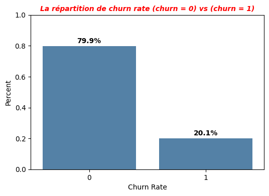

À partir du graphe ci-dessus, on observe que les classes de la variable cible sont déséquilibrées : la classe 0 représente 79,9 % des observations, tandis que la classe 1 ne représente que 20,1 % de l’ensemble des données.

Ce déséquilibre peut engendrer des difficultés lors de l’entraînement des modèles de machine learning, notamment une tendance à privilégier la classe majoritaire (classe 0) au détriment de la classe minoritaire (classe 1). En conséquence, le modèle peut présenter de bonnes performances globales apparentes, tout en étant peu efficace pour identifier correctement les observations appartenant à la classe 1, ce qui se traduit par une augmentation des erreurs de type faux négatifs et une dégradation du recall et du F1-score.

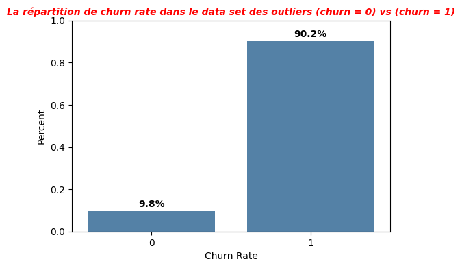

Après avoir détecté les données anormales dans le dataset, on observe, à partir du graphe ci-dessus, que plus de 90 % des outliers appartiennent à la classe 1. Cette observation est cohérente avec le déséquilibre des classes : la classe 1 étant minoritaire, il est attendu que le modèle Isolation Forest considère ces observations comme des anomalies. Ainsi, la détection d’outliers dans ce contexte reflète principalement la rareté naturelle de la classe minoritaire plutôt qu’une erreur ou un bruit dans les données.

Analyse statistique univariée

Cette partie consiste à explorer les données dont on dipose afin de les comprendre et les analyser statistiquement.

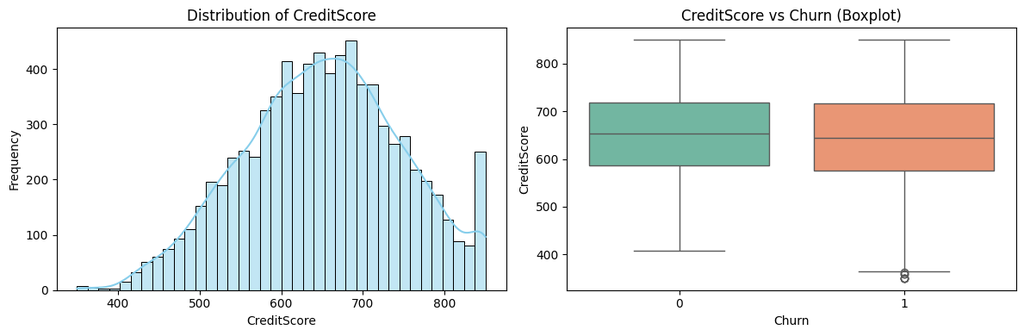

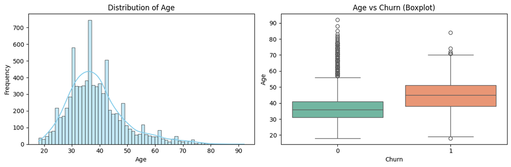

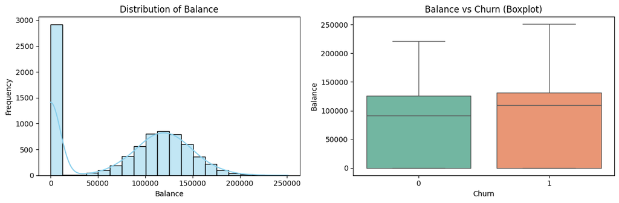

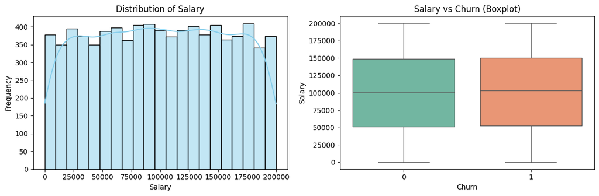

D'après **le boxplot de CreditScore et le Salary** , on peut dire que le Credit score et le salaire ne sont pas des facteurs discriminants puisque leurs distributions sont similaires entre la classe 1 et la classe 0.

En se basant sur le boxplot de l'age, on peut remarquer que la tranche d'âge de 40 à 50 ans ont tendance à churner. Par contre, la tranche d'âge de 30 à 40 ans et celle de 60 ans au plus ont tendance de rester fidèle à l'agence de téléphone mobile.

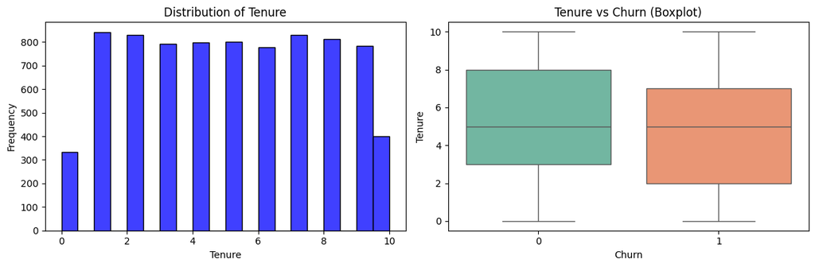

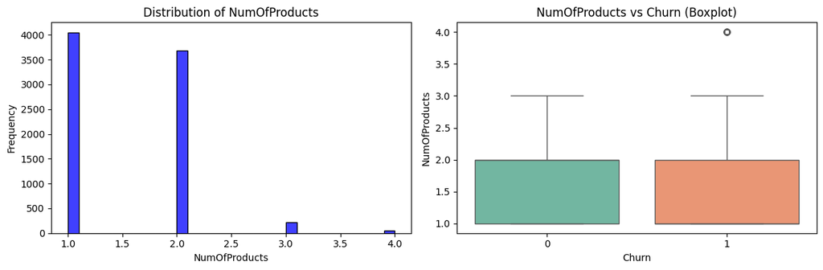

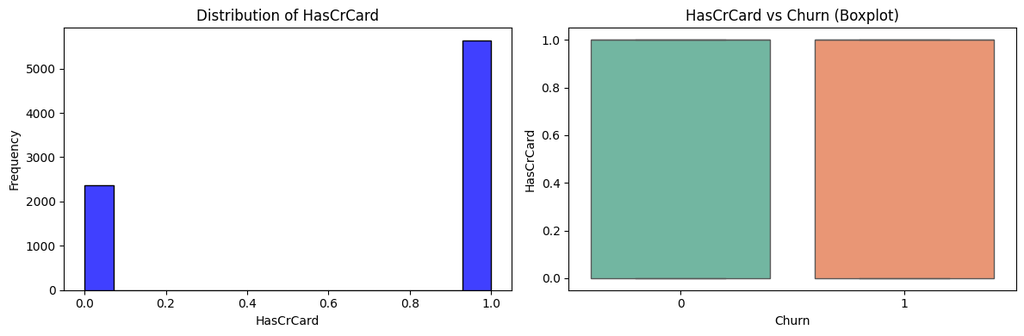

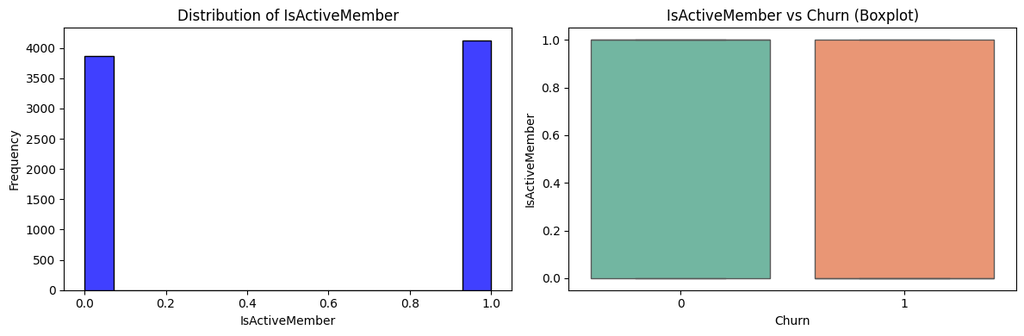

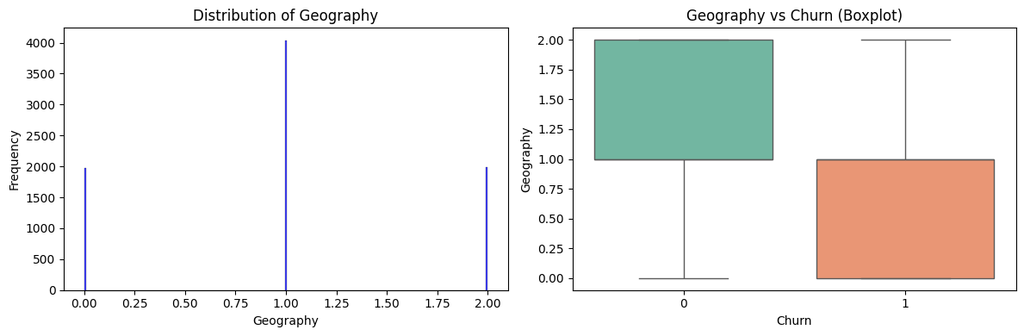

Analyse statistique Bivariée

```
Categorical Columns: ['Geography', 'Gender']
Binary variables: ['HasCrCard', 'IsActiveMember', 'Churn']
Quantitative variables: ['CreditScore', 'Age', 'Balance', 'Salary', 'NumOfProducts', 'Tenure']
```

L'objectif de l'analyse statistique bivariée est d'identifier les différentes relations entre les variables d'entrée deux à deux et de tester des hypothèses sur ces relations. Nous avons diviser nos variables en trois types :

**Variables quantitatives continues :** ['CreditScore', 'Age', 'Balance', 'Salary', 'NumOfProducts', 'Tenure']

**Variables Binaires :** ['HasCrCard', 'IsActiveMember', 'Churn']

**Variables Catégorielles :** ['Geography', 'Gender']

Tests statistiques

```
        Variable          Test     t_stat        p_value  Mean_churn_0  \
3            Age  Welch t-test -26.009375  1.818052e-132     37.436238
1        Balance  Welch t-test -11.012647   1.332580e-27  72330.303489
2    CreditScore  Welch t-test   2.920774   3.524492e-03    652.445314
4  NumOfProducts  Welch t-test   2.737246   6.252176e-03      1.545298
0         Tenure  Welch t-test   2.339227   1.940385e-02      5.051479

   Mean_churn_1
3     44.573027
1  90634.005190
2    644.289621
4      1.487259
0      4.860162
```

**Test de Khi2**

```
       Variable 1      Variable 2        Chi2       p-value  dof
0       Geography          Gender    5.313227  7.018550e-02    2
1       Geography  IsActiveMember    3.150056  2.070018e-01    2
2       Geography       HasCrCard    3.403609  1.823542e-01    2
3       Geography           Churn  196.160108  2.537312e-43    2
4          Gender  IsActiveMember    3.583761  5.834690e-02    1
5          Gender       HasCrCard    0.670241  4.129676e-01    1
6          Gender           Churn   87.569541  8.136807e-21    1
7  IsActiveMember       HasCrCard    1.420153  2.333782e-01    1
8  IsActiveMember           Churn  181.435044  2.355585e-41    1
9       HasCrCard           Churn    0.207113  6.490398e-01    1
```

### Définition des métriques de performance pour la sélection des modèles

Généralement, les métriques utilisées pour évaluer un modèle de machine learning sont les suivants :

- **Accuracy** : mesure la proportion globale de prédictions correctes :  
  *(TP + TN) / (TP + TN + FP + FN)*
- **Precision** : mesure la proportion de prédictions positives correctes :  
  *TP / (TP + FP)*
- **Recall (Sensitivity)** : mesure la capacité du modèle à identifier correctement les observations positives :  
  *TP / (TP + FN)*
- **F1-score** : moyenne harmonique entre la précision et le rappel, particulièrement pertinente dans le cas de **classes déséquilibrées** :  
  *2 × (Precision × Recall) / (Precision + Recall)*
- **Courbe ROC** : représente le *True Positive Rate (Recall)* en fonction du *False Positive Rate* pour l’ensemble des seuils de décision.
- **AUC (Area Under the Curve)** : mesure la capacité globale du modèle à distinguer les classes positives des classes négatives, indépendamment du seuil de classification. Une valeur proche de 1 indique une excellente performance.

Dans le cadre de notre prédiction, les classes churn=0 et churn=1 (classe minoritaire) sont déséquilibrée. Donc, le modèle séléctionné sera évalué en prenant en considération sa capacité à prédire la classe 1 positivement. Donc, nos métriques d'évaluation essentielles seront le **F1-score**et plus particulièrement **le Recall.**

### Modèles de machine learning sans séléction de variables

L'objectif de cette partie est d'entraîner différents modèles de machine learning et séléctionner par la suite le meilleur modèle qui donne le meilleur F1 score et Recall. Cet ensemble de modèles sera entraîné sur la totalité des variables sans selection.

Préparation des donner pour l'entraînement des modèles

```
((6400,), (6400, 10))
```

Entraînement et test des modèles

- Pipelines et entrainement des modèles

**Linear SVC**

```
Training accuracy of SVC model: 0.80609375
Test accuracy of SVC model: 0.805
```

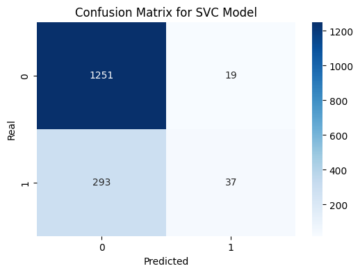

Le problème de prédiction qu'on a signalé lors de l'esploration de la répartition des deux classes est confirmé. Le modèle SVC n'arrive pas à bien prédire les Vrai Positifs à cause de ùinorité des données.

**Random Forest**

```
Training accuracy of RandomForest model: 1.0
Test accuracy of RandomForest model: 0.865
```

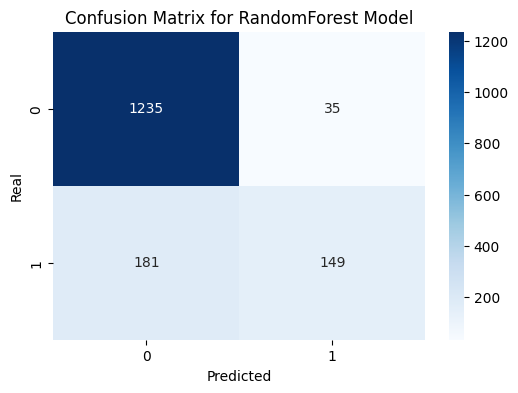

Globalement, le modèle de RandomForest est plus performant que celui de Linear SVC. Il arrive à détecter presque la moitié des vrais positifs de la classe minoritaire. Par contre, il reste encore une amélioration à faire.

**Gradient Boosting**

```
Training accuracy of XGBoost model: 0.8790625
Test accuracy of XGBoost model: 0.86125
```

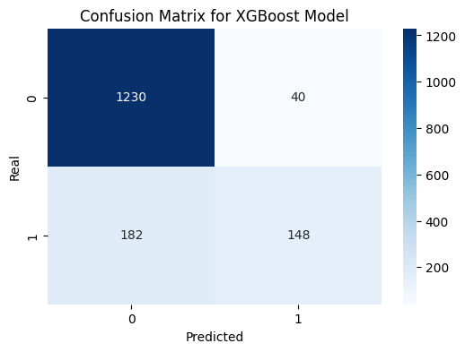

**Stacking**

```
Training accuracy of Stacking model: 0.9175
Test accuracy of Stacking model: 0.866875
```

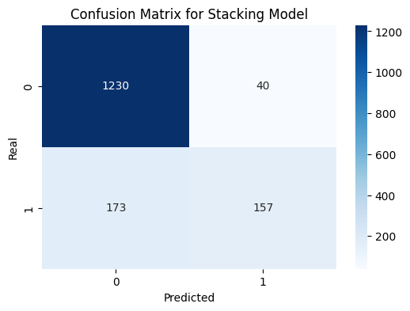

Le modèle Stacking entraîné ci-dessous est bien en terme d'accuracy. Il regroupe les trois modèles entraînés précédement en premier niveau puis la régression logistique en deuxième niveau.

Validation des modèles à l'aide de Cross Validation

L'objectif de cette partie est de valider les performances des modèles entraînés précédement. Pour se faire, on utilisera la Cross Validation avec 5 folds pour récupérer les différentes métriques de chaque modèle.

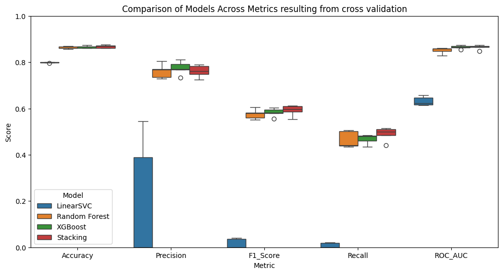

**Conclusion : On choisit le modèle de Stacking comme modèle de base pour la prédiction.**

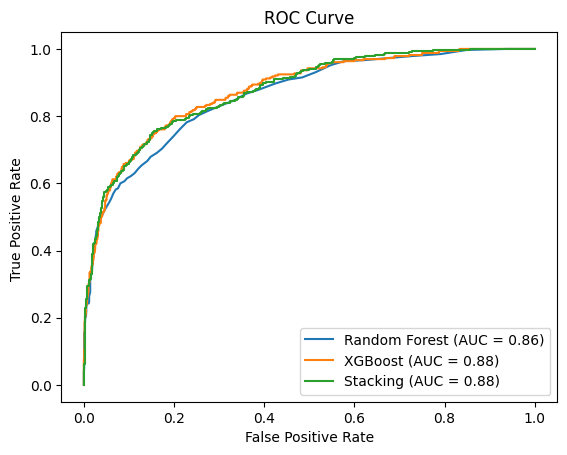

### Modèles de Machine Learning Avec séléction de variables

**Retour sur l'analyse statistique et la significativité des varaibles** On a identifié précedemment que la plupart des variables ne permettent pas d'oberver une séparation des classes . En effet les churner ou non churner sont étalés sur les distributions des variables quantitatives et sur les diagrammes en barre des variables catégorielles. De plus , en appariant les variebles il est difficile d'établir des profils type de churn 0 ou churn 1 à part pour les variables Age et NumberOfProducts qui donnent un semblant tout de même bruité de répartition. Dans la suite on se propose de regarder la régression logistique afin d'améliorer le F1-Score qui est intéressant ici car il est beaucoup plus coûteux de prédire qu'un client qui va se désabonner ne le fera pas que l'inverse. A noter que les modèles d'arbres sophistiqués ne sont pas tellement parvenus à améliorer cette métrique du fait des recouvrements des classes au sur les valeurs des différentes variables qui induit forcément des erreurs lors des choix des arbres.

Régression logistique naive

```
=== Régression logistique naive ===
F1 score (classe 1) : 0.4938820912124583
Accuracy : 0.715625
Recall : 0.6894409937888198
Coefficients :
Age               0.779150
Gender            0.267389
Balance           0.207584
Salary            0.017199
NumOfProducts    -0.027038
HasCrCard        -0.032574
Tenure           -0.033820
CreditScore      -0.076406
Geography        -0.235268
IsActiveMember   -0.920209
dtype: float64
```

La régression logistique bas les modèles en terme de recall avec 0.69. Un faible F1 score est naturellemnt dû à l'augmentation des **faux positifs** dans la précision.

Introduction d'une répartition en classe des âges et nombres de produits achetés

```
--- Modèle avec Age_class_26-35, Age_class_36-45, Age_class_46-55, Age_class_56-65, Age_class_66+ ---
Coefficient : Age_class_26-35    0.101303
Age_class_36-45    1.070626
Age_class_46-55    2.430299
Age_class_56-65    2.217339
Age_class_66+      0.427701
dtype: float64
Recall : 0.6894409937888198
F1 score : 0.4870967741935484

--- Modèle avec NumProducts_class_3-4, NumProducts_class_5+ ---
Coefficient : NumProducts_class_3-4    3.182166
NumProducts_class_5+     0.000000
dtype: float64
Recall : 0.6894409937888198
F1 score : 0.2493368700265252

--- Modèle avec CreditScore ---
Coefficient : CreditScore   -0.075957
dtype: float64
Recall : 0.6894409937888198
F1 score : 0.30985915492957744
```

[output not shown]

[output cut: 38 more lines]

```
=== Modèle combiné ===
Recall : 0.5496894409937888
F1 score : 0.5412844036697247
Coefficients :
NumProducts_class_3-4    3.200958
Age_class_46-55          2.461856
Age_class_56-65          2.227319
Age_class_36-45          1.070217
Age_class_66+            0.529179
Age_class_26-35          0.119914
NumProducts_class_5+     0.000000
CreditScore             -0.051768
dtype: float64
```

Le modèle combiné gagne en précision d'où un F1 score plus élévé mais perd en capacité de bien classer le churn de 1

Influence de la variable 'HasCrCard'

```
=== Modèle sans HasCrCard ===
F1 score : 0.4090909090909091
Coefficients :
IsActiveMember   -0.801768
Gender_1          0.492234
Geography_1      -0.787132
Geography_2      -0.836189
dtype: float64

=== Modèle avec HasCrCard ===
F1 score : 0.4090909090909091
Coefficients :
IsActiveMember   -0.803349
Gender_1          0.491387
Geography_1      -0.787396
Geography_2      -0.837872
HasCrCard        -0.055172
dtype: float64
```

## Partie Amélioration

### Amélioration du modèle choisi sans selection des variables

L'amélioration du modèle Stacking consiste à entraîner le modèle en utilisant des sous modèles performants aves des hyperparamètres optimisés. A partir des résultats précédantes, le Linear SVC n'est pas assez performant dans notre cadre d'étude. On le changera par **l'algorithme de LightGBM.**

```
[LightGBM] [Info] Number of positive: 1279, number of negative: 5121
[LightGBM] [Info] Auto-choosing col-wise multi-threading, the overhead of testing was 0.001488 seconds.
You can set `force_col_wise=true` to remove the overhead.
[LightGBM] [Info] Total Bins 860
[LightGBM] [Info] Number of data points in the train set: 6400, number of used features: 10
[LightGBM] [Info] [binary:BoostFromScore]: pavg=0.500000 -> initscore=-0.000000
[LightGBM] [Info] Start training from score -0.000000
Accuracy score for train dataset : 0.97265625
Accuracy score for test dataset : 0.84
```

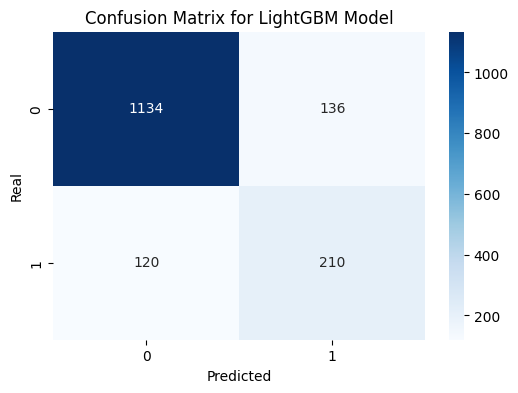

```
Recall score for SVC model : 0.11212121212121212
Recall score for LightGBM model : 0.6363636363636364
Recall score for stacking model : 0.47575757575757577
```

[output not shown]

[output cut: 120 more lines]

[output not shown]

```
LGBM Performances with cross validation_____
Accuracy :  0.8396250000000001
Precision : 0.5942589867346874
F1_score :  0.6152613764934022
Recall :  0.6389253303922138
AUC : 0.8509722387197579
```

A partir des résultats ci-dessous, on remarque que le LightGBM est plus performant que le modèle de stacking en terme de **Recall et F1 Score** . Il arrive à bien détecter **les vrais positifs plus que 63% de la classe minoritaire sont détéctés correctement** .

[output not shown]

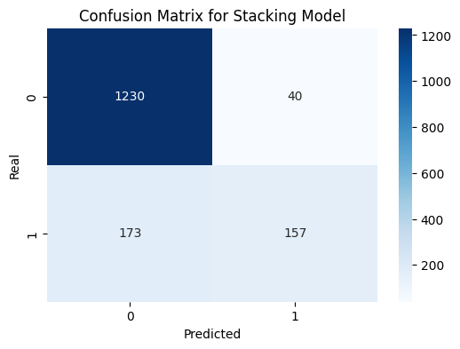

[output not shown]

[output cut: 1012 more lines]

[output not shown]

```
Stacking with LGBM Performances with cross validation_____
Accuracy :  0.86675
Precision : 0.7564158671077562
F1_score :  0.5982537613104267
Recall :  0.4978367291654573
AUC : 0.8674460926939563
```

A partir des résultats précédants, le modèle de LightGBM est plus performant que le stacking model with RF, XGBoost et SVC ou même avec RF, XGBoost et LGBM. Pour améliorer ses perfomance, nous essaierons d'optimiser le LGBM tout en optimisant ses hyperparamètres.

```
Fitting 5 folds for each of 30 candidates, totalling 150 fits
[LightGBM] [Info] Number of positive: 1279, number of negative: 5121
[LightGBM] [Info] Auto-choosing col-wise multi-threading, the overhead of testing was 0.000437 seconds.
You can set `force_col_wise=true` to remove the overhead.
[LightGBM] [Info] Total Bins 860
[LightGBM] [Info] Number of data points in the train set: 6400, number of used features: 10
[LightGBM] [Info] [binary:BoostFromScore]: pavg=0.500000 -> initscore=-0.000000
[LightGBM] [Info] Start training from score -0.000000
```

```
Best parameters: {'subsample': 1.0, 'num_leaves': 15, 'n_estimators': 300, 'min_child_samples': 30, 'max_depth': -1, 'learning_rate': 0.01, 'colsample_bytree': 0.7}
Best CV Recall-score: 0.7325735294117648
```

```
Test Recall: 0.6818181818181818
```

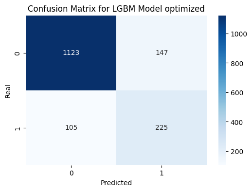

L'idée maintennat est de voir l'influence d'augmentation des données minoritaires sur les performance du LGBM. Donc l'étape qui suit a pour objectif d'augmenter les données de la classe churn=1 à l'aide de **la méthode SMOTE** et puis entraîner **le modèle LGBM optimisé** sur ces données et évaluer ses performances.

```
avant augmentation : 6400
Après augm : 10242
```

```
[LightGBM] [Info] Number of positive: 5121, number of negative: 5121
[LightGBM] [Info] Auto-choosing col-wise multi-threading, the overhead of testing was 0.001775 seconds.
You can set `force_col_wise=true` to remove the overhead.
[LightGBM] [Info] Total Bins 1869
[LightGBM] [Info] Number of data points in the train set: 10242, number of used features: 10
[LightGBM] [Info] [binary:BoostFromScore]: pavg=0.500000 -> initscore=0.000000
Training accuracy of optimized LGBM model on augmented data: 0.8637961335676626
Test accuracy of optimized LGBM model on augmented data: 0.8425
Recall score: 0.6818181818181818
```

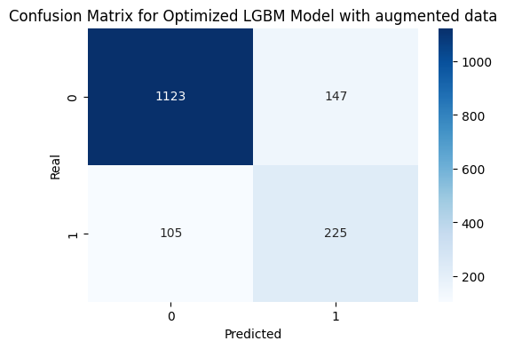

### Conclusion :

Le modèle LightGBM, entraîné avec des hyperparamètres optimisés, présente de très bonnes performances en termes de F1-score et de Recall, aussi bien avec qu’sans augmentation des données de la classe minoritaire.

### Amélioration du modèle choisi avec selection des variables

- **Pénalité Ridge** afin de capter les *effets conjoints* des variables sans annuler leurs coefficients (contrairement à la pénalité Lasso).
- **Optimisation des hyperparamètres** à l’aide de *GridSearch* pour sélectionner la configuration optimale du modèle.
- **Ajustement du seuil de classification** à **0,4** afin d’améliorer la détection des clients à risque (*churn = 1*), combiné à une **pénalisation accrue des erreurs sur cette classe** via l’attribut **balance** du modèle logistique.
- **Discrétisation des variables continues**, notamment l’**âge** et le **nombre de produits achetés**, en classes afin de mieux capturer les comportements non linéaires.

```
Best C: {'C': 1}
        C  Train F1   Test F1  std_test_score
0    0.01  0.507783  0.504507        0.020912
1    0.10  0.522707  0.522608        0.017433
2    1.00  0.522763  0.522814        0.017537
3   10.00  0.522854  0.522608        0.017433
4  100.00  0.522854  0.522608        0.017433
```

```
0.8540372670807453
0.565625
0.44176706827309237
```

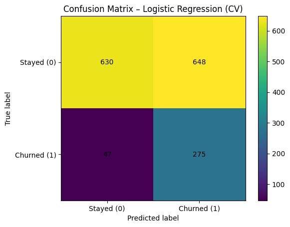

[output not shown]

### Conclusion :

En sélectionnant les variables discriminatives et en les découpant en classe pour obtenir de nouvelles variables catégorielles conformément à l'analyse statistique préliminaire, on arrive déja à avoir de meilleures prédictions pour la classe 1. On accepte de fare des erreurs sur la prédiction de churn_0 afin de pouvoir mieux identifier les clients qui vont effectivement se désabonner.